# IODS course project

# About the project

I’m a PhD student in Genetics/proteonomics. I’m taking this course to refresh my R skills and learn some new stuff.

## Introduction to Open Data Science 2018

[Link to Github Repo](https://github.com/smooshi/IODS-project)

# R Exercise 2 Analysis

## Task 1

Data wrangling exersize is in the data folder.

This dataset contains information about students and their attitude/strategy towards learning and their exam scores.

```r
setwd("~/GitHub/IODS-project/data")
data <- read.table("learning2014.csv", header = TRUE, sep = ",")
head(data)
```

```
##   Gender Age Attitude Points     Deep     Surf  Stra
## 1      F  53       37     25 3.583333 2.583333 3.375
## 2      M  55       31     12 2.916667 3.166667 2.750
## 3      F  49       25     24 3.500000 2.250000 3.625
## 4      M  53       35     10 3.500000 2.250000 3.125
## 5      M  49       37     22 3.666667 2.833333 3.625
## 6      F  38       38     21 4.750000 2.416667 3.625
```

```r
names(data)
```

```
## [1] "Gender"   "Age"      "Attitude" "Points"   "Deep"     "Surf"
## [7] "Stra"
```

```r
dim(data)
```

```
## [1] 183   7
```

There are 7 variables and 183 people.

## Task 2

```r
library(ggplot2)
summary(data)
```

```
##  Gender       Age           Attitude         Points           Deep
##  F:122   Min.   :17.00   Min.   :14.00   Min.   : 0.00   Min.   :1.583
##  M: 61   1st Qu.:21.00   1st Qu.:26.00   1st Qu.:18.00   1st Qu.:3.333
##          Median :22.00   Median :32.00   Median :22.00   Median :3.667
##          Mean   :25.58   Mean   :31.21   Mean   :20.61   Mean   :3.696
##          3rd Qu.:27.00   3rd Qu.:37.00   3rd Qu.:26.00   3rd Qu.:4.083
##          Max.   :55.00   Max.   :50.00   Max.   :33.00   Max.   :4.917
##       Surf            Stra
##  Min.   :1.583   Min.   :1.250
##  1st Qu.:2.417   1st Qu.:2.562
##  Median :2.833   Median :3.125
##  Mean   :2.792   Mean   :3.085
##  3rd Qu.:3.167   3rd Qu.:3.625
##  Max.   :4.333   Max.   :5.000
```

Summary of all variables. Dataset is about students (Age, Gender) and their attitudes towards learning (Attitude, Deep, Stra, Surf) and their combined scores (Points). Combination stats like Deep/Surf/Stra combine several questions from the questionairre togetger.

Deep is a combination of questionaire questions that reflect “Deep Approach” to learning. (Seeking Meaning, Relating Ideas, Use of Evidence)

Surf is a “Surface Approach” to learning. (Lack of Purpose, Unrelated Memorizing, Syllabus-boundness)

Stra is a “Strategic Approach” to learning. (Organized Studying, Time Management)

I will use the graphical library ggplot to do graphics.

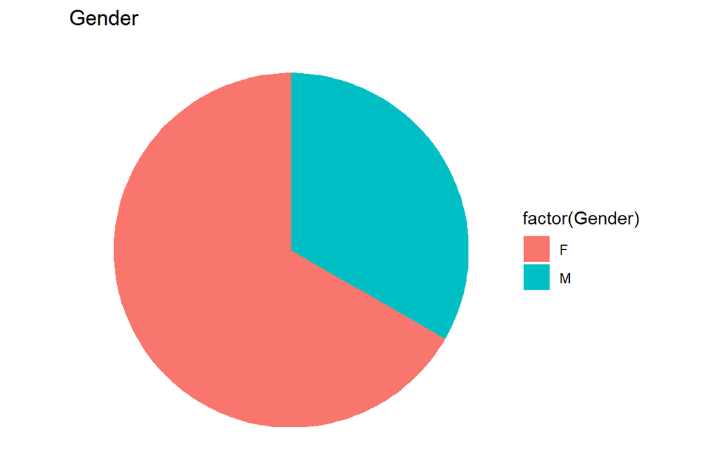

```r
#Pie chart of gender
ggplot(data, aes(x=factor(1), fill = factor(Gender)))+geom_bar(width=1)+coord_polar(theta="y")+theme_void()+labs(title="Gender")
```

There are 122 females and 61 males.

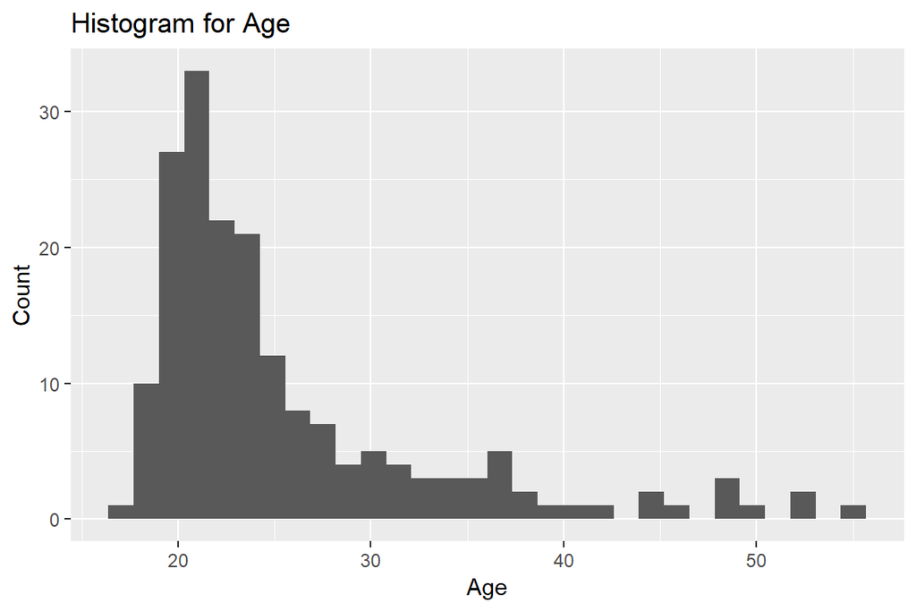

```r
#Histogram of Age
qplot(data$Age, geom="histogram")+labs(title="Histogram for Age") +
  labs(x="Age", y="Count")
```

Age distribution is slanted, there are a lot more people in their 20’s than other people. Age groups cannot really be compared directly because the amount of people are so different.

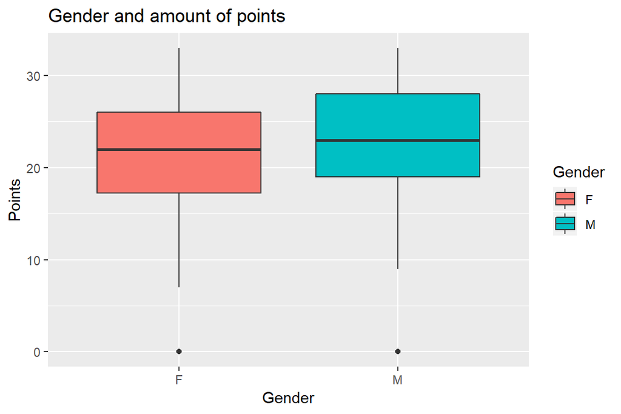

```r
#Boxplot of gender and points

ggplot(data, aes(x=Gender, y=Points, fill=Gender)) +
  geom_boxplot()+labs(title="Gender and amount of points")
```

Points and Attitude:

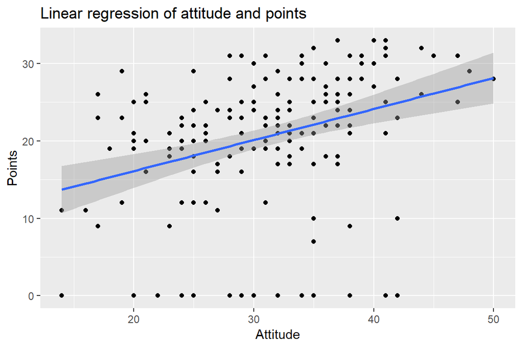

```r
#Linear regression of Attitude and Points
ggplot(data, aes(x = Attitude, y = Points)) + geom_point() + geom_smooth(method="lm")+labs(title="Linear regression of attitude and points")
```

```r
cor.test(data$Attitude, data$Points, method="pearson")
```

```
##
##  Pearson's product-moment correlation
##
## data:  data$Attitude and data$Points
## t = 4.8513, df = 181, p-value = 2.635e-06
## alternative hypothesis: true correlation is not equal to 0
## 95 percent confidence interval:
##  0.2042082 0.4615619
## sample estimates:
##       cor
## 0.3392167
```

Test of simple linear regression. Pearson correlation is significant and low positive, 0.339. (Pearson correlation assumes normalcy, not sure if it applies here)

Scatter plot matrix:

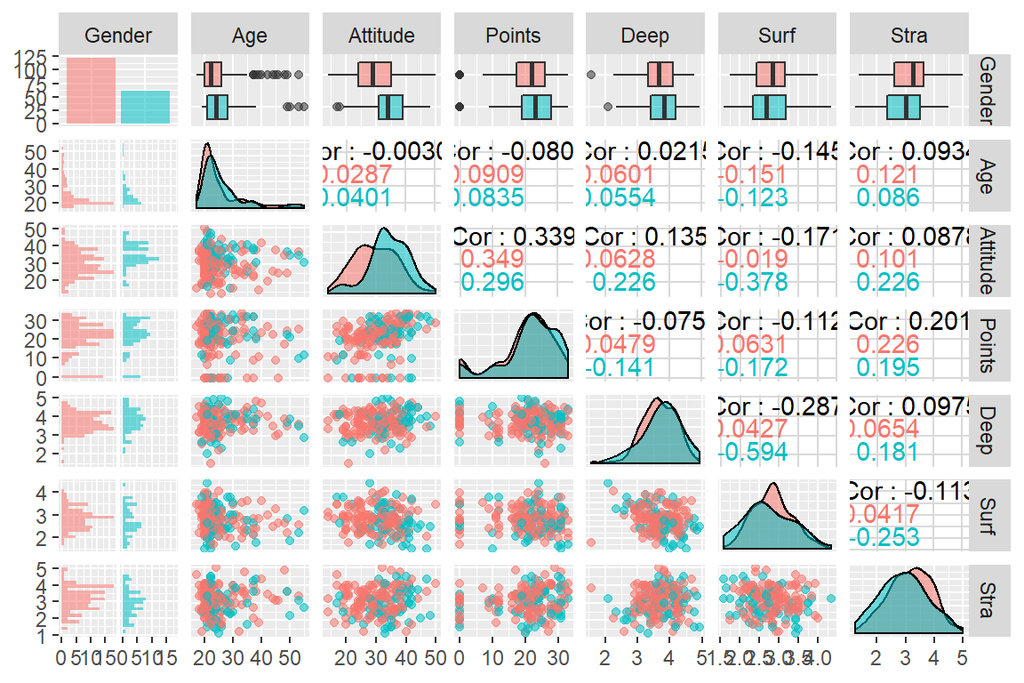

```r
library(GGally)
p <- ggpairs(data, mapping = aes(col=Gender, alpha=0.3), lower = list(combo = wrap("facethist", bins = 20)))
p
```

Compilation of all sorts of different statistics.

## Task 3 & 4

### Task 3

Target: Points

```r
linear <- lm(Points ~ Gender+Age+Attitude, data=data)
summary(linear)
```

```
##
## Call:
## lm(formula = Points ~ Gender + Age + Attitude, data = data)
##
## Residuals:
##     Min      1Q  Median      3Q     Max
## -25.153  -2.520   1.716   5.411  13.022
##
## Coefficients:
##             Estimate Std. Error t value Pr(>|t|)
## (Intercept) 10.23020    3.39239   3.016  0.00294 **
## GenderM     -0.39852    1.35699  -0.294  0.76934
## Age         -0.08766    0.07944  -1.103  0.27133
## Attitude     0.40862    0.08707   4.693 5.33e-06 ***
## ---
## Signif. codes:  0 '***' 0.001 '**' 0.01 '*' 0.05 '.' 0.1 ' ' 1
##
## Residual standard error: 8.196 on 179 degrees of freedom
## Multiple R-squared:  0.1218, Adjusted R-squared:  0.1071
## F-statistic: 8.278 on 3 and 179 DF,  p-value: 3.465e-05
```

This correlation is not significant for gender and age, but is for attitude. I will keep Attitude and remove Gender, Age.

```r
summary(lm(Points~Attitude+Stra+Surf, data=data))
```

```
##
## Call:
## lm(formula = Points ~ Attitude + Stra + Surf, data = data)
##
## Residuals:
##     Min      1Q  Median      3Q     Max
## -25.151  -3.212   2.233   5.257  13.694
##
## Coefficients:
##             Estimate Std. Error t value Pr(>|t|)
## (Intercept)  4.77806    5.15767   0.926   0.3555
## Attitude     0.37570    0.08308   4.522 1.11e-05 ***
## Stra         1.89680    0.78318   2.422   0.0164 *
## Surf        -0.62623    1.14945  -0.545   0.5866
## ---
## Signif. codes:  0 '***' 0.001 '**' 0.01 '*' 0.05 '.' 0.1 ' ' 1
##
## Residual standard error: 8.082 on 179 degrees of freedom
## Multiple R-squared:  0.146,  Adjusted R-squared:  0.1317
## F-statistic:  10.2 on 3 and 179 DF,  p-value: 3.089e-06
```

Linear regression is significant for Attitude and Stra, but not Surf. Remove Surf.

### Task 4

```r
summary(lm(Points~Attitude+Stra+Deep, data=data))
```

```
##
## Call:
## lm(formula = Points ~ Attitude + Stra + Deep, data = data)
##
## Residuals:
##     Min      1Q  Median      3Q     Max
## -23.499  -2.557   1.755   5.097  15.420
##
## Coefficients:
##             Estimate Std. Error t value Pr(>|t|)
## (Intercept)  9.69651    4.84553   2.001  0.04689 *
## Attitude     0.40408    0.08178   4.941 1.78e-06 ***
## Stra         2.07504    0.77411   2.681  0.00804 **
## Deep        -2.19240    1.08585  -2.019  0.04497 *
## ---
## Signif. codes:  0 '***' 0.001 '**' 0.01 '*' 0.05 '.' 0.1 ' ' 1
##
## Residual standard error: 7.998 on 179 degrees of freedom
## Multiple R-squared:  0.1637, Adjusted R-squared:  0.1496
## F-statistic: 11.68 on 3 and 179 DF,  p-value: 5.036e-07
```

R-squared is a statistical measure of how close the data are to the fitted regression line. If the data formed linearly on the regression line, R-squared would be 1 or close to 1. Multiple R-squared is low and that says that these variables do not explain the whole variation in exam points. There are other factors that affect the distribution/orientation of the data.

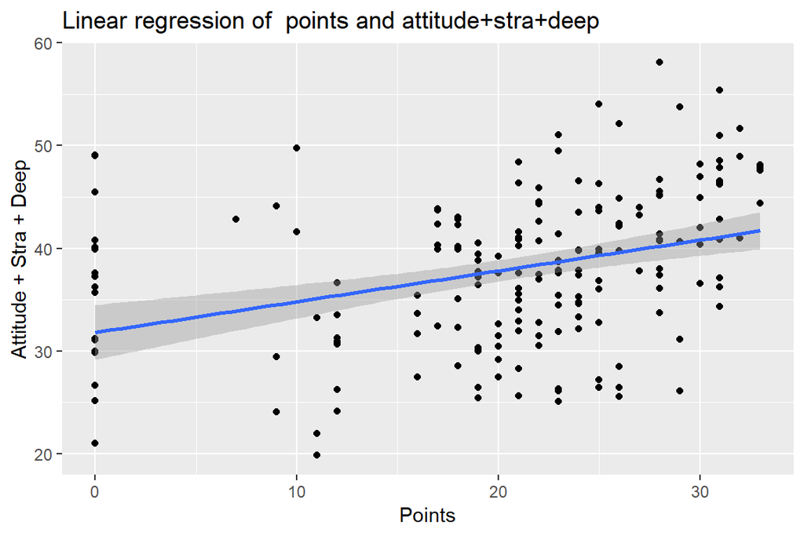

```r
ggplot(data, aes(x=Points, y=Attitude+Stra+Deep))+geom_point()+geom_smooth(method="lm")+labs(title="Linear regression of  points and attitude+stra+deep")
```

In the picture there’s slight positive linear correlation between Points and Attitude+Stra+Deep, meaning higher scores for an individual in Attitude+Stra+Deep generally mean there’s also a higher Points. While Points correlates with Attitude+Stra+Deep, those variables do not explain all variation in Points. Other factors that could affect points might be how familiar the student is with the course material previously and how much absolute time they spent on studying.

## Task 5

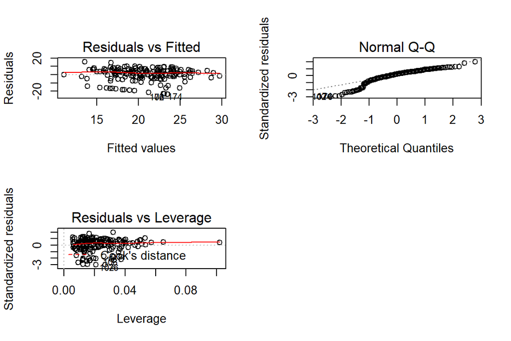

```r
linear <- lm(Points~Attitude+Stra+Deep, data=data)
par(mfrow = c(2,2))
plot(linear, which = c(1,2,5))
```

Q-Q Plot shows that the left tail of the distribution does not follow normalcy. It deviates a lot. I assume left tail contains all the “0 points” people, who answered the questions but possibly didn’t show up for the exam (0 points.) These people should be in a real analysis of the data.

There is also high spread in residuals, but they look mostly grouped linearly.

There is one higher leverage outlier in the data at 0.10 Leverage, while others are mostly between 0.0-0.04.

# Chapter 3

## Task 1-2

```r
setwd("~/GitHub/IODS-project/data")
alc <- read.table("~/GitHub/IODS-project/data/alc.csv", header = TRUE, sep = ",")
names(alc)
```

```
##  [1] "school"     "sex"        "age"        "address"    "famsize"
##  [6] "Pstatus"    "Medu"       "Fedu"       "Mjob"       "Fjob"
## [11] "reason"     "nursery"    "internet"   "guardian"   "traveltime"
## [16] "studytime"  "failures"   "schoolsup"  "famsup"     "paid"
## [21] "activities" "higher"     "romantic"   "famrel"     "freetime"
## [26] "goout"      "Dalc"       "Walc"       "health"     "absences"
## [31] "G1"         "G2"         "G3"         "alc_use"    "high_use"
```

This is a dataset made from two Portuguese school data attributes include descriptors of students (like age, sex, family size, profession of mom and dad, grades etc) and alcohol usage (Dalc = workday alcohol consumption, Walc = weekend alcohol consumption). Alc_use combines Dalc and Walk, and high_use is alcohol usage that’s higher than 2 (1- very low, 5- very high).

## Task 3-4

### Age

Legal drinking age in Portugal is 16 for beer/cider and 18 for hard liquor. I would hope that there are significantly more high alchohol users in students that are of legal drinking age.

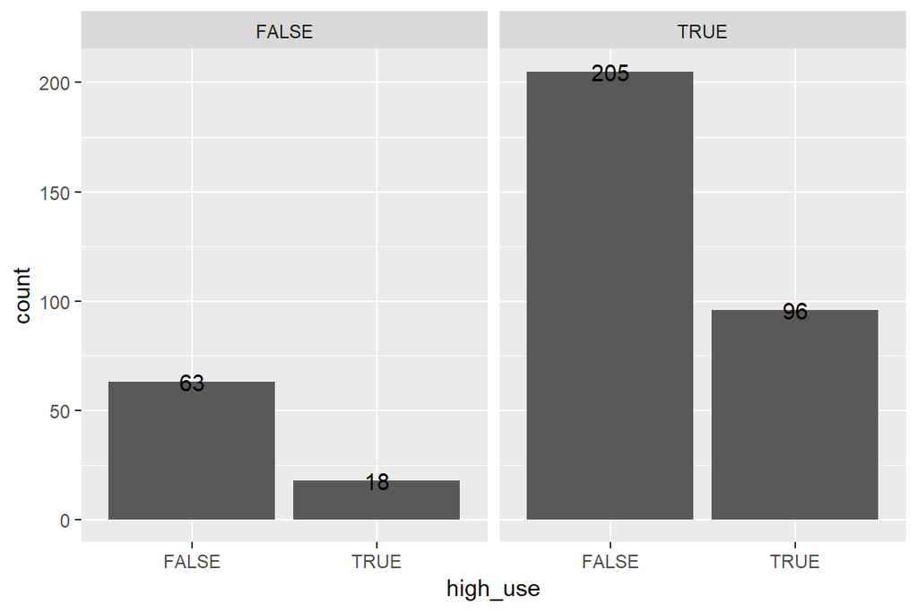

```r
library(ggplot2)
alc$legal <- ifelse(alc$age >= 16, TRUE, FALSE)
ggplot(data = alc, aes(x=high_use))+geom_bar()+facet_wrap("legal")+geom_text(stat='count', aes(label=..count..))
```

```r
#Students under legal drinking age that are high users
18/(63+18)
```

```
## [1] 0.2222222
```

```r
#Students over legal drinking age that are high users
96/(205+96)
```

```
## [1] 0.3189369
```

Here groupings are based on is the student legal drinking age (TRUE/FALSE). The graph shows that there are much more responders that are of legal drinking age. Percentage of students that are high users and under the legal drinking age is 22% and number of students that are high users and over the legal drinking age is 32%. There’s a noticable difference.

### Go out

26 goout - going out with friends (numeric: from 1 - very low to 5 - very high)

Assumption: Kids that go out alot with their friends are more likely to drink than those who don’t.

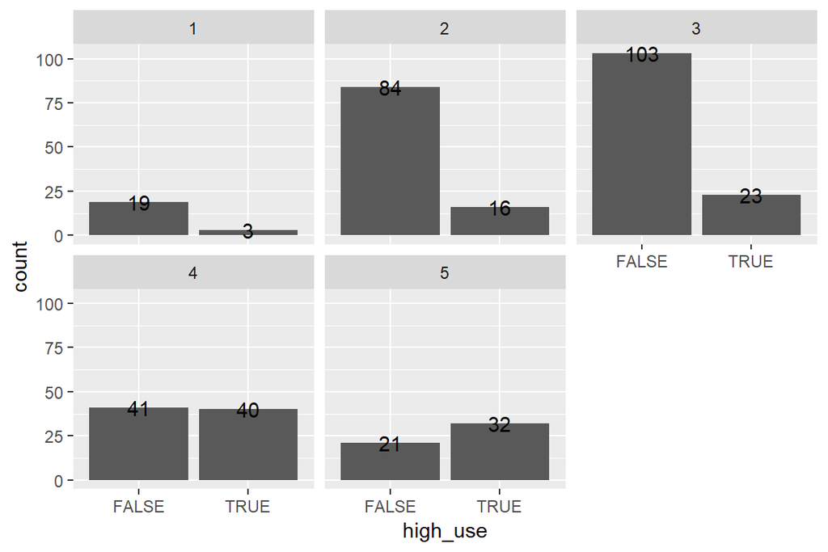

```r
ggplot(data = alc, aes(x=high_use))+geom_bar()+facet_wrap("goout")+geom_text(stat='count', aes(label=..count..))
```

```r
ftable(table(alc$high_use, alc$goout))
```

```
##          1   2   3   4   5
##
## FALSE   19  84 103  41  21
## TRUE     3  16  23  40  32
```

Here it’s very obvious, kids that go out a lot drink a lot more than kids that don’t go out much.

### Grades

Assumption: Kids who get more than half the points in every grade (First period, second period, final grade) are less likely to drink a lot than kids than don’t even manage half the points.

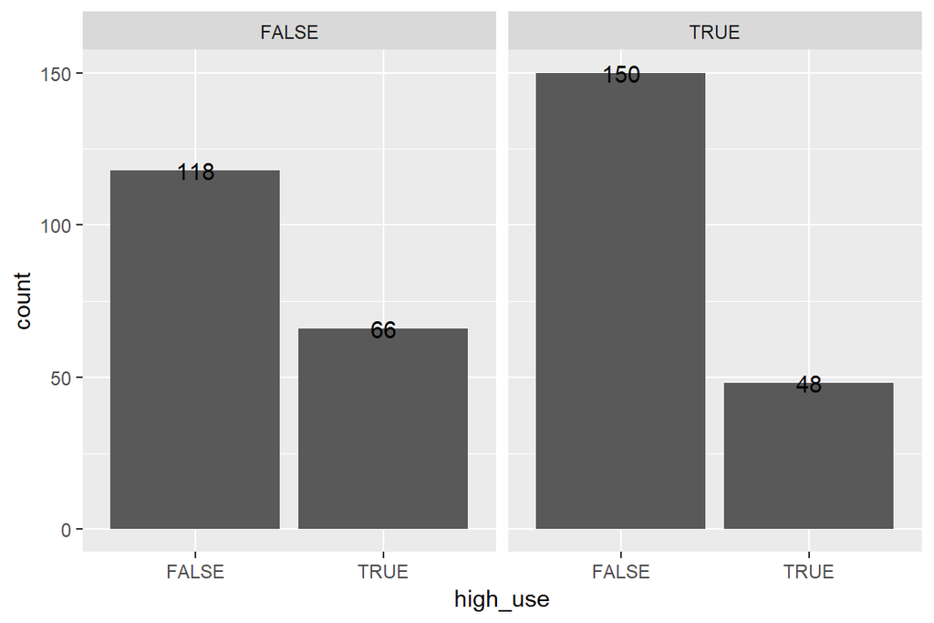

```r
alc$grades <- ifelse(alc$G1 >= 11 & alc$G2 >= 11 & alc$G3 >=11, TRUE, FALSE)
ggplot(data = alc, aes(x=high_use))+geom_bar()+facet_wrap("grades")+geom_text(stat='count', aes(label=..count..))
```

```r
#false
66/(66+118)
```

```
## [1] 0.3586957
```

```r
#true
48/(48+150)
```

```
## [1] 0.2424242
```

This looks like it might be significant, kids that get more than half the points are 24% high alcohol users and kids that don’t are 35.9% high alchohol users.

### Studytime

Assumption: Kids who spend more time studying drink less.

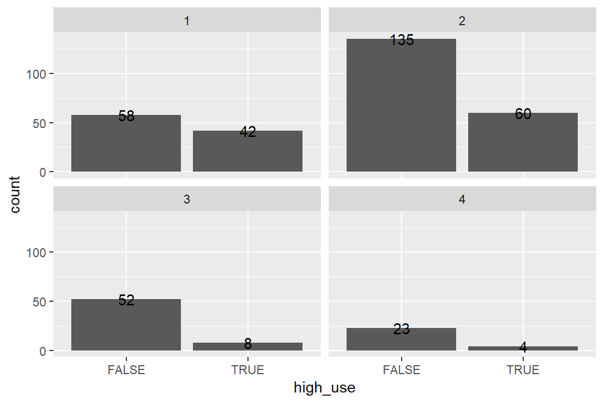

```r
ggplot(data = alc, aes(x=high_use))+geom_bar()+facet_wrap("studytime")+geom_text(stat='count', aes(label=..count..))
```

```r
ftable(table(alc$high_use, alc$studytime))
```

```
##          1   2   3   4
##
## FALSE   58 135  52  23
## TRUE    42  60   8   4
```

```r
#1 < 2hours
42/(42+58)
```

```
## [1] 0.42
```

```r
#2 2 to 5 hours
60/(60+135)
```

```
## [1] 0.3076923
```

```r
#3 5 to 10 hours
8/(8+52)
```

```
## [1] 0.1333333
```

```r
#4 over 10 hours
4/(4+23)
```

```
## [1] 0.1481481
```

Here it’s pretty clear, kids that study more than 5 hours a week are much less likely to be drinkers (14.8%, 13.3%) and kids who study less are much more likely to be heavy drinkers ( 30.7% and 42%). Especially if the kids spend almost no time studying (<2).

## Task 5

### Age

```r
m <- glm(high_use ~ legal, data = alc, family = "binomial")
summary(m)
```

```
##
## Call:
## glm(formula = high_use ~ legal, family = "binomial", data = alc)
##
## Deviance Residuals:
##     Min       1Q   Median       3Q      Max
## -0.8765  -0.8765  -0.8765   1.5118   1.7344
##
## Coefficients:
##             Estimate Std. Error z value Pr(>|z|)
## (Intercept)  -1.2528     0.2673  -4.687 2.77e-06 ***
## legalTRUE     0.4941     0.2945   1.678   0.0934 .
## ---
## Signif. codes:  0 '***' 0.001 '**' 0.01 '*' 0.05 '.' 0.1 ' ' 1
##
## (Dispersion parameter for binomial family taken to be 1)
##
##     Null deviance: 465.68  on 381  degrees of freedom
## Residual deviance: 462.70  on 380  degrees of freedom
## AIC: 466.7
##
## Number of Fisher Scoring iterations: 4
```

```r
coef(m)
```

```
## (Intercept)   legalTRUE
##  -1.2527630   0.4941012
```

```r
confint(m)
```

```
##                   2.5 %     97.5 %
## (Intercept) -1.80548222 -0.7512117
## legalTRUE   -0.06548363  1.0947388
```

Age is not significant factor in 95% statistical significance, but would be 90% statistical significance.

### Go out

```r
m <- glm(high_use ~ goout, data = alc, family = "binomial")
summary(m)
```

```
##
## Call:
## glm(formula = high_use ~ goout, family = "binomial", data = alc)
##
## Deviance Residuals:
##     Min       1Q   Median       3Q      Max
## -1.3721  -0.7672  -0.5450   0.9945   2.3082
##
## Coefficients:
##             Estimate Std. Error z value Pr(>|z|)
## (Intercept)  -3.3512     0.4151  -8.073 6.84e-16 ***
## goout         0.7596     0.1157   6.564 5.23e-11 ***
## ---
## Signif. codes:  0 '***' 0.001 '**' 0.01 '*' 0.05 '.' 0.1 ' ' 1
##
## (Dispersion parameter for binomial family taken to be 1)
##
##     Null deviance: 465.68  on 381  degrees of freedom
## Residual deviance: 415.68  on 380  degrees of freedom
## AIC: 419.68
##
## Number of Fisher Scoring iterations: 4
```

```r
coef(m)
```

```
## (Intercept)       goout
##  -3.3511801   0.7596076
```

```r
confint(m)
```

```
##                  2.5 %     97.5 %
## (Intercept) -4.1958512 -2.5655359
## goout        0.5385448  0.9931232
```

How often kids go “out” with their friends is significant factor that explains high alcohol use.

### Grades

```r
m <- glm(high_use ~ grades, data = alc, family = "binomial")
summary(m)
```

```
##
## Call:
## glm(formula = high_use ~ grades, family = "binomial", data = alc)
##
## Deviance Residuals:
##     Min       1Q   Median       3Q      Max
## -0.9426  -0.9426  -0.7452   1.4320   1.6835
##
## Coefficients:
##             Estimate Std. Error z value Pr(>|z|)
## (Intercept)  -0.5810     0.1537   -3.78 0.000157 ***
## gradesTRUE   -0.5584     0.2261   -2.47 0.013526 *
## ---
## Signif. codes:  0 '***' 0.001 '**' 0.01 '*' 0.05 '.' 0.1 ' ' 1
##
## (Dispersion parameter for binomial family taken to be 1)
##
##     Null deviance: 465.68  on 381  degrees of freedom
## Residual deviance: 459.51  on 380  degrees of freedom
## AIC: 463.51
##
## Number of Fisher Scoring iterations: 4
```

```r
coef(m)
```

```
## (Intercept)  gradesTRUE
##  -0.5810299  -0.5584044
```

```r
confint(m)
```

```
##                  2.5 %     97.5 %
## (Intercept) -0.8871701 -0.2834717
## gradesTRUE  -1.0051883 -0.1174594
```

Bad grades mean kid is more likely to be a high alcohol user and higher grades mean low chance.

### Studytime

```r
m <- glm(high_use ~ studytime, data = alc, family = "binomial")
summary(m)
```

```
##
## Call:
## glm(formula = high_use ~ studytime, family = "binomial", data = alc)
##
## Deviance Residuals:
##     Min       1Q   Median       3Q      Max
## -1.0603  -0.8314  -0.8314   1.2993   2.1010
##
## Coefficients:
##             Estimate Std. Error z value Pr(>|z|)
## (Intercept)   0.3209     0.3076   1.043    0.297
## studytime    -0.6029     0.1530  -3.941  8.1e-05 ***
## ---
## Signif. codes:  0 '***' 0.001 '**' 0.01 '*' 0.05 '.' 0.1 ' ' 1
##
## (Dispersion parameter for binomial family taken to be 1)
##
##     Null deviance: 465.68  on 381  degrees of freedom
## Residual deviance: 448.31  on 380  degrees of freedom
## AIC: 452.31
##
## Number of Fisher Scoring iterations: 4
```

```r
coef(m)
```

```
## (Intercept)   studytime
##   0.3209036  -0.6028561
```

```r
confint(m)
```

```
##                  2.5 %     97.5 %
## (Intercept) -0.2772274  0.9308876
## studytime   -0.9123998 -0.3115583
```

If a kid spends a lot tipe studying they are less likely to be high alchohol users.

## Exersize 6

Go out, Grades, STudytime

```r
library(dplyr)
m <- glm(high_use ~ studytime+grades+goout, data = alc, family = "binomial")
summary(m)
```

```
##
## Call:
## glm(formula = high_use ~ studytime + grades + goout, family = "binomial",
##     data = alc)
##
## Deviance Residuals:
##     Min       1Q   Median       3Q      Max
## -1.6683  -0.8015  -0.5478   0.9613   2.5753
##
## Coefficients:
##             Estimate Std. Error z value Pr(>|z|)
## (Intercept)  -1.9907     0.5184  -3.840 0.000123 ***
## studytime    -0.5737     0.1659  -3.459 0.000543 ***
## gradesTRUE   -0.3014     0.2485  -1.213 0.225280
## goout         0.7340     0.1171   6.269 3.64e-10 ***
## ---
## Signif. codes:  0 '***' 0.001 '**' 0.01 '*' 0.05 '.' 0.1 ' ' 1
##
## (Dispersion parameter for binomial family taken to be 1)
##
##     Null deviance: 465.68  on 381  degrees of freedom
## Residual deviance: 399.34  on 378  degrees of freedom
## AIC: 407.34
##
## Number of Fisher Scoring iterations: 4
```

```r
coef(m)
```

```
## (Intercept)   studytime  gradesTRUE       goout
##  -1.9906826  -0.5736953  -0.3013601   0.7340343
```

```r
confint(m)
```

```
##                  2.5 %     97.5 %
## (Intercept) -3.0311038 -0.9938476
## studytime   -0.9097114 -0.2575669
## gradesTRUE  -0.7897173  0.1864329
## goout        0.5103598  0.9703992
```

```r
p <- predict(m, type="response")
# add the predicted probabilities to 'alc'
alc <- mutate(alc, probability = p)

# use the probabilities to make a prediction of high_use
alc <- mutate(alc, prediction = probability > 0.5)

table(high_use = alc$high_use, prediction = alc$prediction) %>% prop.table() %>% addmargins()
```

```
##         prediction
## high_use      FALSE       TRUE        Sum
##    FALSE 0.64659686 0.05497382 0.70157068
##    TRUE  0.19109948 0.10732984 0.29842932
##    Sum   0.83769634 0.16230366 1.00000000
```

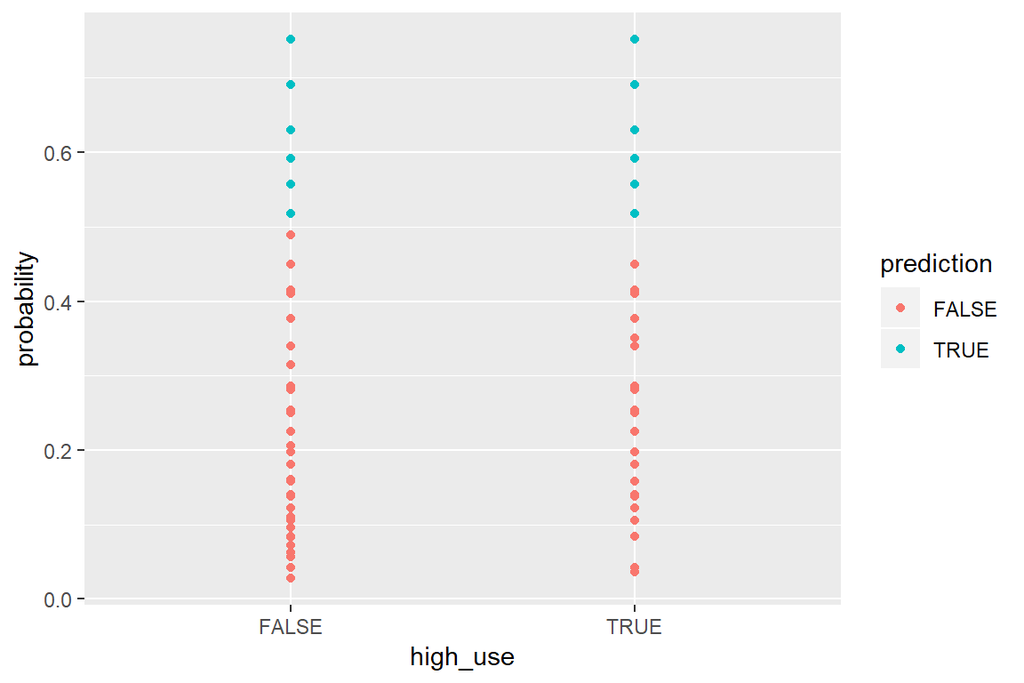

```r
g <- ggplot(alc, aes(x = high_use, y = probability, col=prediction))

g + geom_point()
```

```r
# define a loss function (mean prediction error)
loss_func <- function(class, prob) {
  n_wrong <- abs(class - prob) > 0.5
  mean(n_wrong)
}

# call loss_func to compute the average number of wrong predictions in the (training) data
loss_func(class = alc$high_use, prob = alc$probability)
```

```
## [1] 0.2460733
```

There’s a 25% chance of a wrong prediction, so I don’t think my variables are a excellent predictor. It would predict “mostly”, but there’s such a big chance of error it’s not good/usable. Also there’s probably a lot of “overlap” between go out and studytime and studytime and grades… Different predictors would have maybe captured more of the actual problem?

## Exersize 7

```r
library(boot)
cv <- cv.glm(data = alc, cost = loss_func, glmfit = m, K = 10)

# average number of wrong predictions in the cross validation
cv$delta[1]
```

```
## [1] 0.2460733
```

Datacamp model was 0.26 and mine is 0.25… SO they are pretty much the same?

Trying to get a better model:

```r
m <- glm(high_use ~ studytime+failures+goout+absences+sex, data = alc, family = "binomial")
summary(m)
```

```
##
## Call:
## glm(formula = high_use ~ studytime + failures + goout + absences +
##     sex, family = "binomial", data = alc)
##
## Deviance Residuals:
##     Min       1Q   Median       3Q      Max
## -2.0668  -0.7736  -0.5080   0.7663   2.4984
##
## Coefficients:
##             Estimate Std. Error z value Pr(>|z|)
## (Intercept) -3.27654    0.59805  -5.479 4.28e-08 ***
## studytime   -0.38032    0.17414  -2.184 0.028966 *
## failures     0.24195    0.21713   1.114 0.265141
## goout        0.71219    0.12037   5.917 3.28e-09 ***
## absences     0.07748    0.02242   3.456 0.000548 ***
## sexM         0.76991    0.26620   2.892 0.003825 **
## ---
## Signif. codes:  0 '***' 0.001 '**' 0.01 '*' 0.05 '.' 0.1 ' ' 1
##
## (Dispersion parameter for binomial family taken to be 1)
##
##     Null deviance: 465.68  on 381  degrees of freedom
## Residual deviance: 380.06  on 376  degrees of freedom
## AIC: 392.06
##
## Number of Fisher Scoring iterations: 4
```

```r
coef(m)
```

```
## (Intercept)   studytime    failures       goout    absences        sexM
## -3.27653834 -0.38032241  0.24195066  0.71218501  0.07747656  0.76991496
```

```r
confint(m)
```

```
##                   2.5 %      97.5 %
## (Intercept) -4.48345712 -2.13293535
## studytime   -0.73128369 -0.04615332
## failures    -0.18407800  0.67190587
## goout        0.48205204  0.95506124
## absences     0.03450819  0.12366371
## sexM         0.25194047  1.29791469
```

```r
p <- predict(m, type="response")
# add the predicted probabilities to 'alc'
alc <- mutate(alc, probability = p)

# use the probabilities to make a prediction of high_use
alc <- mutate(alc, prediction = probability > 0.5)

table(high_use = alc$high_use, prediction = alc$prediction) %>% prop.table() %>% addmargins()
```

```
##         prediction
## high_use      FALSE       TRUE        Sum
##    FALSE 0.65968586 0.04188482 0.70157068
##    TRUE  0.17015707 0.12827225 0.29842932
##    Sum   0.82984293 0.17015707 1.00000000
```

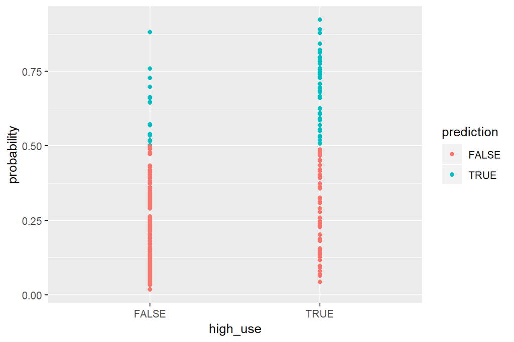

```r
g <- ggplot(alc, aes(x = high_use, y = probability, col=prediction))

g + geom_point()
```

```r
# define a loss function (mean prediction error)
loss_func <- function(class, prob) {
  n_wrong <- abs(class - prob) > 0.5
  mean(n_wrong)
}

# call loss_func to compute the average number of wrong predictions in the (training) data
loss_func(class = alc$high_use, prob = alc$probability)
```

```
## [1] 0.2120419
```

```r
cv <- cv.glm(data = alc, cost = loss_func, glmfit = m, K = 10)

# average number of wrong predictions in the cross validation
cv$delta[1]
```

```
## [1] 0.2172775
```